# Basic pathview exploration

Connor Morgan-Lang

November 14, 2018

This tutorial is meant to take your KEGG Ortholog (KO) annotation tables from KAAS, and one of the rpkm files (.csv format) and view a pathway or metabolic map with these data layered on.

Before you begin loading, transforming, and playing with data we will need to load the following libraries at the very least:

```r
library(tidyr)
library(dplyr)
library(pathview)
library(RColorBrewer)
library(knitr)
```

Now we are going to read our tabular files. First is KO annotation tables (query.ko.txt) then the rpkm file. I’m using rename to assign names to each of the columns as these do not have headers.

```r
ko <- read.table("~/Desktop/MICB405_TAship/MICB405-Metagenomics/2018/testing/SaanichInlet_150m_MAG_ORFs.KAAS.tsv") %>%
  dplyr::rename(orf = V1) %>%
  dplyr::rename(ko = V2)
metat_rpkm <- read.table("~/Desktop/MICB405_TAship/MICB405-Metagenomics/2018/testing/SI042_SaanichInlet_150m_MAG_ORFs_rpkm.txt", sep=',') %>%
  dplyr::rename(orf = V1) %>%
  dplyr::rename(rpkm = V2)

prokka_mag_map <- read.table("~/Desktop/MICB405_TAship/MICB405-Metagenomics/2018/testing/Prokka_MAG_map.csv", header=F, sep=',') %>%
  dplyr::rename(prokka_id = V1) %>%
  dplyr::rename(mag = V2)

arc_class <- read.table("~/Desktop/MICB405_TAship/MICB405-Metagenomics/2018/testing/gtdbtk.ar122.classification_pplacer.tsv", sep="\t")
bac_class <- read.table("~/Desktop/MICB405_TAship/MICB405-Metagenomics/2018/testing/gtdbtk.bac120.classification_pplacer.tsv", sep="\t")
gtdb_dat <- rbind(arc_class, bac_class) %>%
  dplyr::rename(mag = V1) %>%
  separate(V2, sep=';', into=c("Kingdom", "Phylum", "Class", "Order", "Family", "Genus", "Species"))

checkm_dat <- read.table("~/Desktop/MICB405_TAship/MICB405-Metagenomics/2018/testing/MetaBAT2_SaanichInlet_150m_min1500_checkM_stdout.tsv",
                         header=TRUE,
                         sep="\t",
                         comment.char = '') %>%
  dplyr::rename(mag = Bin.Id) %>%
  dplyr::select(mag, Completeness, Contamination)

# Due to a bug in the renaming script we have to rename the bins. Its a bit hacky but works using tidyverse functions
metag_rpkm <- read.table("~/Desktop/MICB405_TAship/MICB405-Metagenomics/2018/testing/SaanichInlet_150m_binned.rpkm.csv", header=T, sep=',') %>%
  mutate(Sequence = gsub('m_', 'm.', Sequence)) %>%
  mutate(Sequence = gsub('Inlet_', 'Inlet.', Sequence)) %>%
  separate(col=Sequence, into=c("mag", "contig"), sep='_', extra="merge") %>%
  group_by(Sample, mag) %>%
  summarise(g_rpkm = sum(RPKM)) %>%
  mutate(mag = gsub('Inlet.', 'Inlet_', mag))
```

Here are the tables in their current form, ready for merging by `orf`:

| orf | ko |
| --- | --- |
| DHFFMCEN_00035 | K02004 |
| DHFFMCEN_00037 | K02003 |
| DHFFMCEN_00039 | K03058 |
| DHFFMCEN_00070 | K10896 |
| DHFFMCEN_00072 | K00364 |
| DHFFMCEN_00104 | K13148 |

| orf | rpkm |
| --- | --- |
| AJHEAEGA_00001 | 0.0000000 |
| AJHEAEGA_00002 | 0.0000000 |
| AJHEAEGA_00003 | 0.0000000 |
| AJHEAEGA_00004 | 0.0000000 |
| AJHEAEGA_00005 | 0.0000000 |
| AJHEAEGA_00006 | 0.0989954 |

We can also determine the number of Phyla present in our bins, and how many MAGs are representing each. Of course, you can do this for all the taxonomic ranks. I’m also going to remove the Genus and Species fields since these are probably not relevant to your analysis (if so, then skip that step) and not very trustworthy given the whole binning procedure.

```r
gtdb_dat %>%
  group_by(Phylum) %>%
  summarise(count = n_distinct(mag)) %>%
  kable()
```

| Phylum | count |
| --- | --- |
| p__Bacteroidota | 4 |
| p__Bdellovibrionota | 1 |
| p__Chloroflexota | 2 |
| p__Cloacimonadota | 1 |
| p__Crenarchaeota | 1 |
| p__Dadabacteria | 1 |
| p__Dependentiae | 2 |
| p__Desulfobacterota | 1 |
| p__Elusimicrobiota | 1 |
| p__Latescibacterota | 2 |
| p__Margulisbacteria | 1 |
| p__Marinisomatota | 4 |
| p__Micrarchaeota | 1 |
| p__Nanoarchaeota | 11 |
| p__Patescibacteria | 11 |
| p__Planctomycetota | 1 |
| p__Proteobacteria | 11 |
| p__Thermoplasmatota | 2 |
| p__Verrucomicrobiota | 1 |

```r
gtdb_dat <- dplyr::select(gtdb_dat, mag, Kingdom, Phylum, Class, Order, Family)
```

The `summarise` code is summing all RPKM values assigned to a KO number for each MAG. This is useful to prevent multiple rows in an eventual matrix for pathview for each copy found. Or accidentally dropping those data if we’re not careful. Anyway, we can freely sum RPKM values and that is what is easiest here.

**NOTE**: If your are dealing with RPKM values from multiple cruises (in this example I am only dealing with RPKM from SI042) you will also need to group by a `cruise` variable so these are not summed. Or maybe you want them to be if you are not interested in the time/season/cruise variable. If you are interested in visualizing the variability in transcription of a single MAG across the cruises you may also want to `filter` for your MAG of interest then group by `ko` and `cruise`. It all depends on what question you want to answer so be mindful here!

```r
rpkm_dat <- left_join(ko, metat_rpkm, by="orf") %>%
  separate(orf, into=c("prokka_id", "orf_id")) %>% # Split the Prokka ORF names into MAG identifier and ORF number for joining
  left_join(prokka_mag_map, by="prokka_id") %>%
  left_join(gtdb_dat, by="mag") %>%
  left_join(checkm_dat, by="mag")

# If you also wanted to add the RPKM abundance values from the metagenome:
  # left_join(metag_rpkm, by="mag")

head(rpkm_dat) %>% kable()
```

| prokka_id | orf_id | ko | rpkm | mag | Kingdom | Phylum | Class | Order | Family | Completeness | Contamination |
| --- | --- | --- | --- | --- | --- | --- | --- | --- | --- | --- | --- |
| DHFFMCEN | 00035 | K02004 | 0 | SaanichInlet_150m.101 | d__Archaea | p__Nanoarchaeota | c__Woesearchaeia | o__Pacearchaeales | f__GW2011-AR1 | 63.08 | 0 |
| DHFFMCEN | 00037 | K02003 | 0 | SaanichInlet_150m.101 | d__Archaea | p__Nanoarchaeota | c__Woesearchaeia | o__Pacearchaeales | f__GW2011-AR1 | 63.08 | 0 |
| DHFFMCEN | 00039 | K03058 | 0 | SaanichInlet_150m.101 | d__Archaea | p__Nanoarchaeota | c__Woesearchaeia | o__Pacearchaeales | f__GW2011-AR1 | 63.08 | 0 |
| DHFFMCEN | 00070 | K10896 | 0 | SaanichInlet_150m.101 | d__Archaea | p__Nanoarchaeota | c__Woesearchaeia | o__Pacearchaeales | f__GW2011-AR1 | 63.08 | 0 |
| DHFFMCEN | 00072 | K00364 | 0 | SaanichInlet_150m.101 | d__Archaea | p__Nanoarchaeota | c__Woesearchaeia | o__Pacearchaeales | f__GW2011-AR1 | 63.08 | 0 |
| DHFFMCEN | 00104 | K13148 | 0 | SaanichInlet_150m.101 | d__Archaea | p__Nanoarchaeota | c__Woesearchaeia | o__Pacearchaeales | f__GW2011-AR1 | 63.08 | 0 |

Depending on your research question, you may want to subset your data by just the MAGs with the greatest completeness and least contamination, or by a taxonomy. Or, if you are wondering what the metabolic potential is of the entire community (well, at least the portion that was binned) you may want to aggregate the KO numbers by a taxonomic rank.

**NOTE**: some sort of aggregation or subsetting is probably essential with `pathview` since it has an upper limit of the number of samples that can be visualized… and by sample I mean MAG, cruise, or taxon. Really, this comes down to the number of columns in the final matrix you pass off to `pathview`. However, I recently found that updating your R version to 3.5.1 and installing the latest version of `pathview` increases this number to some as of yet unknown limit!

```r
# Subset by taxon
ko_rpkm <- rpkm_dat %>%
  filter(Phylum %in% c("p__Proteobacteria", "p__Nanoarchaeota", "p__Thermoplasmatota")) %>%
  group_by(mag, ko) %>%
  summarise(t_rpkm = sum(rpkm)) %>%
  spread(key = mag, value = t_rpkm)

# Subset by completeness and contamination
ko_rpkm <- rpkm_dat %>%
  filter(Completeness >= 90 & Contamination < 5) %>%
  group_by(mag, ko) %>%
  summarise(t_rpkm = sum(rpkm)) %>%
  spread(key = mag, value = t_rpkm)

# Aggregate by a taxonomy, still summing RPKM of each KO number. You could use mean() instead.
ko_rpkm <- rpkm_dat %>%
  group_by(Class, ko) %>%
  summarise(t_rpkm = sum(rpkm)) %>%
  spread(key = Class, value = t_rpkm)

pv_mat <- dplyr::select(ko_rpkm, -ko)
rownames(pv_mat) <- ko_rpkm$ko
```

As an example, we can view the nitrogen metabolism capabilities of our MAGs. To view a different pathway or metabolism the `pathway.id` parameter will need to be changed. Searching for your pathway of interest via the KEGG browser is likely the easiest way to find these IDs.

I’ve also spiced up our scale at the top with some help from [colorbrewer2](http://colorbrewer2.org/#type=sequential&scheme=BuGn&n=3). I highly suggest visiting this website whenever you’re searching for a colour palette! Conveniently, there is an `RColorBrewer` library that you can use to automatically apply built-in and custom colour palettes in your `ggplot` visualizations.

```r
# Nitrogen metabolism
pv.out <- pathview(gene.data = pv_mat,
                   limit = list(gene = c(0,10)),
                   low = list(gene = "#91bfdb"),
                   mid = list(gene = "#ffffbf"),
                   high = list(gene = "#fc8d59"),
                   species = "ko",
                   pathway.id="00910",
                   kegg.dir = "~/Desktop/MICB405_TAship/MICB405-Metagenomics/2018/")
```

Here is a file that pathview automatically writes to your `kegg.dir` directory.

**NOTE**: If the files are not showing up in your `kegg.dir` directory, they are probably being written elsewhere on your laptop, probably in the current working directory of R. You can change this directory by using `setwd()` and providing it the path to where it should write the files.

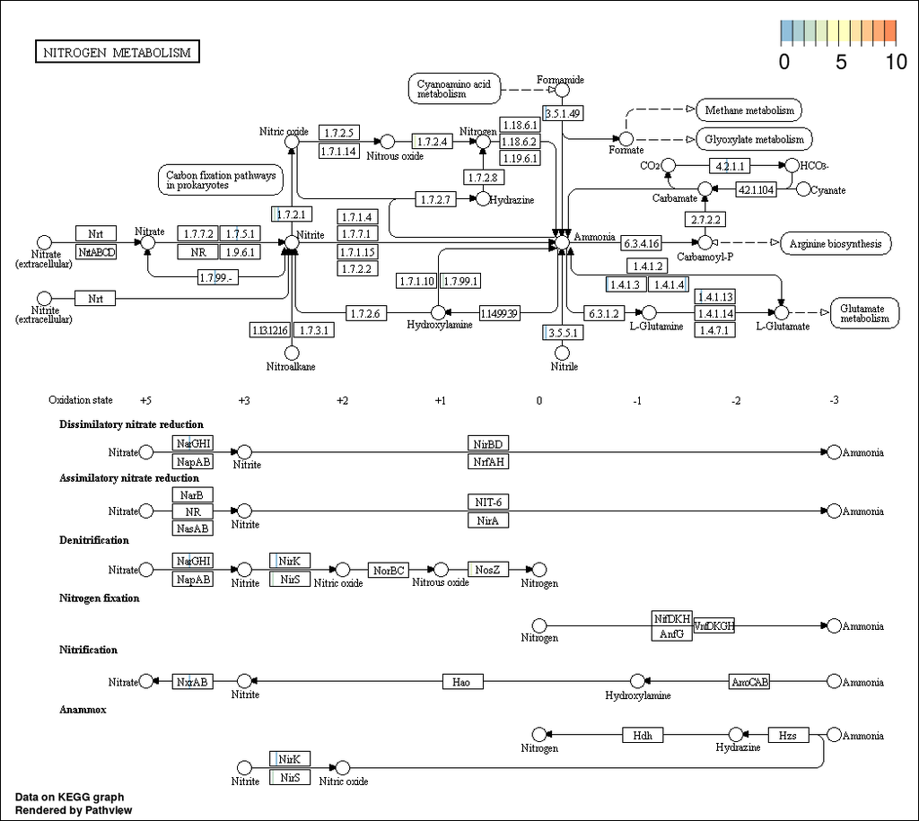